# Lab 2 Solution Proposal

##### (c)

We make the plots in a similar way.

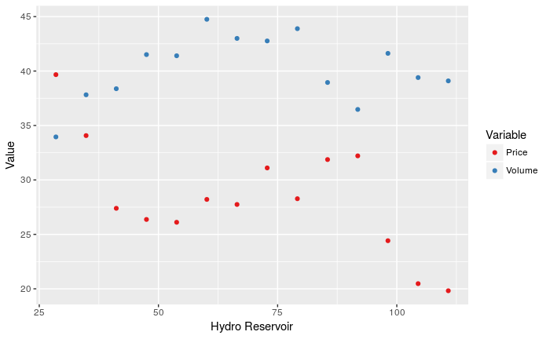

```r
elmarket %>%
    select(hydrores,price,volume) %>%
    rename("Price"=price,"Volume"=volume) %>%
    mutate(Volume=Volume) %>%
    gather(key="Variable",value="Value",-hydrores) %>%
ggplot(aes(x=hydrores,y=Value,color=Variable)) +
        stat_summary_bin(fun.y="mean",bins=13,geom="point") +
    scale_color_brewer(palette = "Set1") +
    labs(x="Hydro Reservoir")
```

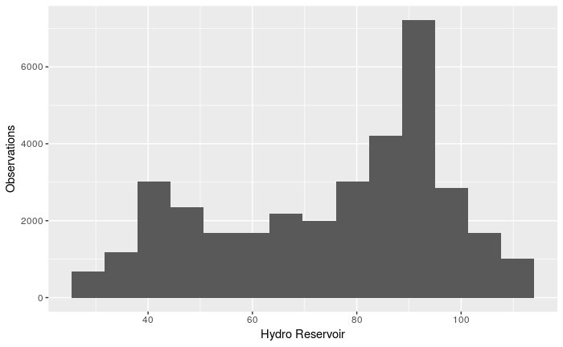

```r
ggplot(data=elmarket,aes(x=hydrores,y=volume)) +
    stat_summary_bin(fun.y=function(y) length(y),bins=13,geom="col") +
    labs(x="Hydro Reservoir",y="Observations")
```

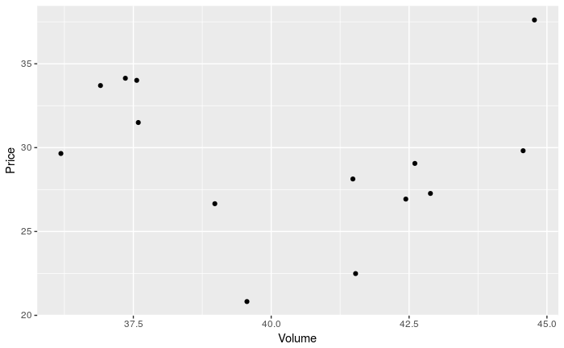

```r
elmarket %>%
    mutate(hydrobin=cut_number(hydrores,13)) %>%
    group_by(hydrobin) %>%
    summarize(meanvolume=mean(volume),
              meanprice=mean(price)) %>%
    ggplot(aes(x=meanvolume,y=meanprice)) +
    geom_point() +
    labs(x="Volume",y="Price")
```

The plots of the averages within bins of hydro reservoir amounts without any controls do not look nearly as good as the ones using temperature. The relationship between volume and reservoirs and price and reservoirs do not display a clear direction, and the VIV-plot do not seem to show any clear direction between volume and price when averaged within bins of reservoir stocks.

From the aggregate plots of hydro reservoirs - thinking about what they tell us and how they relate to the problem of the producers in this market - it is not necessarily surprising that we at least need to control for seasonality in the hydro stocks to have a hope of getting anywhere in this market.

##### (d)

We residualize the variables with respect to hour, month, year, nortemp and swetemp.

```r
hydrores_res <- residuals(lm(hydrores ~ hour + month + year + nortemp + swetemp,
                            data=elmarket)) + mean(elmarket$nortemp,na.rm=TRUE)
price_res <- residuals(lm(price ~ hour + month + year + nortemp + swetemp,
                            data=elmarket)) + mean(elmarket$price,na.rm=TRUE)
volume_res <- residuals(lm(volume ~ hour + month + year + nortemp + swetemp,
                            data=elmarket)) + mean(elmarket$volume,na.rm=TRUE)
```

As before we add the residualized variables to the subset of the dataset where hydrores is non-missing.

```r
elmarket_subs <- cbind(elmarket[!is.na(elmarket$hydrores),],
                       hydrores_res,
                       price_res=price_res[!is.na(elmarket$hydrores)],
                       volume_res=volume_res[!is.na(elmarket$hydrores)])
```

Now we can calculate the values and make the plots.

```r
bindata <- elmarket_subs %>%
    mutate(hydrobin=cut_number(hydrores_res,13,labels=FALSE)) %>%
    group_by(hydrobin) %>%
    summarize(meanprice=mean(price_res),
              meanvolume=mean(volume_res),
              hydrores=mean(hydrores_res),
              observations=n())
```

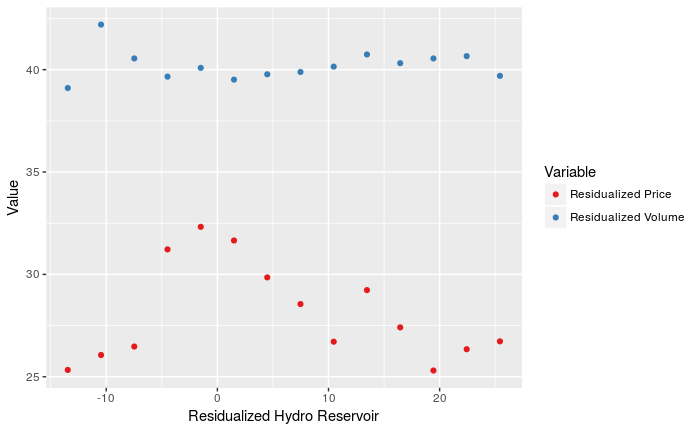

```r
elmarket_subs %>%
    select(hydrores_res,price_res,volume_res) %>%
    mutate(volume_res=volume_res) %>%
    rename("Residualized Price"=price_res,"Residualized Volume"=volume_res) %>%
    gather(key="Variable",value="Value",-hydrores_res) %>%
ggplot(aes(x=hydrores_res,y=Value,color=Variable)) +
        stat_summary_bin(fun.y="mean",bins=13,geom="point") +
    scale_color_brewer(palette = "Set1") +
    labs(x="Residualized Hydro Reservoir")
```

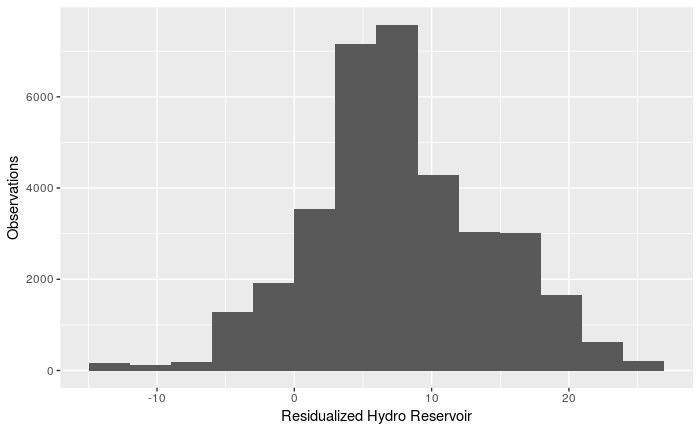

```r
ggplot(data=elmarket_subs,aes(x=hydrores_res,y=volume_res)) +
    stat_summary_bin(fun.y=function(y) length(y),bins=13,geom="col") +
    labs(x="Residualized Hydro Reservoir",y="Observations")
```

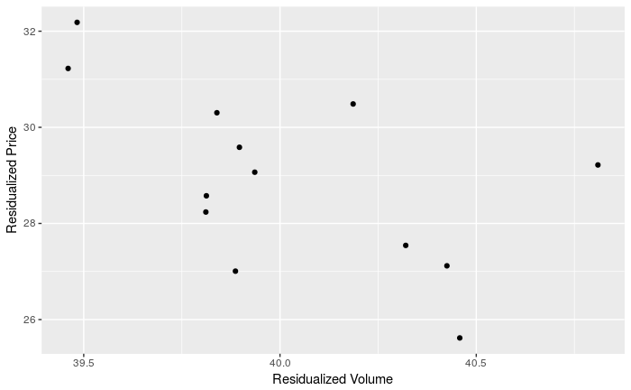

```r
elmarket_subs %>%
    mutate(hydrobin=cut_number(hydrores_res,13)) %>%
    group_by(hydrobin) %>%
    summarize(meanvolume=mean(volume_res),
              meanprice=mean(price_res)) %>%
    ggplot(aes(x=meanvolume,y=meanprice)) +
    geom_point() +
    labs(x="Residualized Volume",y="Residualized Price")
```

From the bar graph of number of observations in each bin, we see that the number of observations in the bins is quite uneven. This isn’t necessarily a problem, though it tells us something about what variation in hydro reservoir capacity is likely to drive our results, when we control for the factors included here.

The graph of bin-average volume and price over the bins shows by and large that volume tends to increase and price tends to decrease when there is more water in the reservoirs (after residualizing). Still, the pattern isn’t as stable as for temperature, which could be a sign that the relationship is “noisy” (in a statistical sense), that there are omitted variables responsible for generating non-linearities, or that the relationship actually features non-linearities.

Looking at the scatter of price and volume within bins against each other, we see that the major feature seems to be a downwarding sloping relationship, as we would expect from a demand schedule. (Note that all of the plots here will be sensitive to our binning strategy, at least to some extent, for instance to how many bins we create and the range of values in each bin)

#### 12. Extra:

##### (a)

An approximate answer to this can be found by inspecting the VIV-plots of volume against price for both temperature and hydro reserves. This basically shows us the effective range in which our instruments “move” the variables of interest.

This means that for temperature, we can think of the effective in-sample variation in price being in the range between 20 and 40 EUR/MWh, and 33 to 45 MWh for volume. For hydro reserves, the values seems to largely fall in the range 25 to 32 EUR/MWh for price, and 39 to 41 MWh for volume.

Saying anything specific about supply (for the variation induced by temperature) or demand (for the variation induced by hydro reserves) outside of this range will have to be considered as extrapolation based on the functional form, and should be considered even more uncertain than our in-sample values. When doing forecasting, the formulas for errors (for instance for generating confidence intervals on the forecast) will to some extent increase as we get further away from the central values in the sample, though this will still only account for sampling variation uncertainty around the specified functional form, and not any uncertainty that arises due to us not actually being able to inspect whether the functional relationship actually continues outside of the effective variation we have in the sample (where the functional relationship is linear in our regressions above).

Note: The values for effective variation we get from the VIV-plots is bascially the thing we want (net of some truncation of values due to discretization/“binning”) - the value of price and volume after removing the effect of our control variables (residualization/partialling out). This means that there is a larger range of prices and volumes where we are not yet into the land of extrapolation, as long as values outside of the range can be attributed to our control variables (i.e., we are within the range once we partial out the control variables).

Note 2: How certain we should feel about our estimates of the curves on any point along it should also be considered in light of the amount of observations we have in the area around that point. If you look at the bar graphs for number of observations in the temperature bins (after residualizing), we shouldn’t feel as confident about the supply curve for the values induced by temperatures under 0 degrees and above 15 degrees, as we should for values betwen 5 and 10 degrees.

##### (b)

Since neither the supply curve nor the demand curve is uniquely defined here (varies by hour, month, year and temperature), we need to do some choices. I will use the demand and supply curves at 16h (4pm) in February 2014, at the average temperatures for this month. One could also calculate several and average, or simulate (bootstrap) over the curves to get at the uncertainty in the estimates of the changes in volumes, prices and surplus (this would be the “right” thing to do if we were giving input to public policy, for instance). This isn’t necessarily hard to do, but is outside the scope of this course (though you might feasibly explore such options for your term paper).

Technical comment: Note that if we consider the slope parameters as fixed (not accounting for the statistical uncertainty in these), then the only uncertainty will be in the changes in surplus, since the change in price, volume and deadweight loss is only a function of the slope parameters and the size of the tax (in the linear case we have here).

Since they are linear curves, all we need is an intercept and the slope of each. Demand:

```r
demand_iv <- ivreg(volume ~ price + nortemp + swetemp + hour + month + year |
                       hydrores + nortemp + swetemp + hour + month + year,
                   data=elmarket)
```

Effective demand intercept at average temperatures 16h, February 2014:

```r
elmarket %>%
    filter(hour==16, month==2 & year ==2014) %>%
    summarize(nortemp=mean(nortemp),
              swetemp=mean(swetemp))
```

| nortemp | swetemp |
| --- | --- |
| 3.506561 | 3.258486 |

```r
constD <- demand_iv$coefficients[["(Intercept)"]] +
    demand_iv$coefficients[["nortemp"]] * 3.51 +
    demand_iv$coefficients[["swetemp"]] * 3.26 +
    demand_iv$coefficients[["hour16"]] +
    demand_iv$coefficients[["month2"]] +
    demand_iv$coefficients[["year2014"]]
```

Store slope parameter

```r
alphaD = demand_iv$coefficients[["price"]]
```

Supply

```r
supply_iv <- ivreg(volume ~ price + hydrores + month + year |
                                    nortemp + swetemp + hydrores + hour + month + year,
                                data=elmarket)
```

Effective supply intercept at average hydro reserves February 2014:

```r
elmarket %>%
    filter(year==2014 & month==2) %>%
    summarize(hydrores=mean(hydrores,na.rm=TRUE))
```

| hydrores |
| --- |
| 63.02961 |

```r
constS <- supply_iv$coefficients[["(Intercept)"]] +
    supply_iv$coefficients[["hydrores"]] * 63 +
    supply_iv$coefficients[["month2"]] +
    supply_iv$coefficients[["year2014"]]
```

Store slope parameter

```r
alphaS <- supply_iv$coefficients[["price"]]
```

Equilibrium price and volume implied by model as market currently looks like: (Solution to demand = supply <=> constD + alphaD * P = constS + alphaS * P)

Equilibrium price before tax increase

```r
pretaxprice = (constD - constS) / (alphaS - alphaD)
pretaxprice
```

```
[1] 32.7487
```

Equilibrium volume before tax increase

```r
pretaxvol = constD + alphaD * pretaxprice
pretaxvol
```

```
[1] 49.57234
```

Calculate post-tax price and volume (deduct two from price per unit in supply, such that the price we calculate has the interpretation of price to consumers. (Solution to demand = supply <=> constD + alphaD * P = constS + alphaS * (P - 2))

Equilibrium price after tax increase

```r
posttaxprice = (constD - constS + alphaS * 2) / (alphaS - alphaD)
posttaxvol = constD + alphaD * posttaxprice
```

```r
posttaxprice
```

```
[1] 34.51887
```

Post Tax Volume

```r
posttaxvol
```

```
[1] 49.2633
```

Change in price from tax increase

```r
posttaxprice - pretaxprice
```

```
[1] 1.770177
```

Change in volume from tax increase

```r
posttaxvol - pretaxvol
```

```
[1] -0.3090377
```

See that price to consumers increase by 1.8 EUR/MWh, while volume transacted in the market decreases by 309 MWh (per hour)

Calculate change in consumer surplus - Additional payment on units still bought, plus willingness to pay for units no longer bought (can use triangle formula with linear demand)

```r
(posttaxprice - pretaxprice) * posttaxvol + (posttaxprice - pretaxprice) * (pretaxvol - posttaxvol) / 2
```

```
[1] 87.47827
```

To put things in perspective, remember that this is a measure for an hour - in practice, we would probably translate it to a yearly measure, and show it as a percentage of pre-tax consumer surplus (we can do this for this hour, and show that it is roughly 1.3% of consumer surplus pre-tax - left as an exercise)

Calculate change in producer surplus (Note that price received by the producers are two EUR less per unit than the price received by consumers due to tax wedge)

```r
    (pretaxprice - (posttaxprice - 2)) * posttaxvol +
    (pretaxprice - (posttaxprice - 2)) * (pretaxvol - posttaxvol) / 2
```

```
[1] 11.35737
```

The deadweight loss is equal to the consumer and producer surplus for the units no longer sold, which can be simplified in the following way (with linear demand and supply):

```r
    2 * (pretaxvol - posttaxvol) / 2
```

```
[1] 0.3090377
```

where the difference between DWL and total change in CS and PS is made up by the tax revenues on units still transacted:

```r
    2 * posttaxvol
```

```
[1] 98.5266
```

One can note that the deadweight loss is quite small here, amounting to about 0.3% of tax revenues. We also see that consumers carry most of the tax, taking about 90% of the increase (1.8 EUR). Looking at the demand and supply in this market, we see that demand responds much less to prices than supply, and also has a very low elasticity in an absolute sense.

A classical result in the study of taxation shows that the incidence (who effectively pays the tax) will depend on the relative size of elasticity, where the least elastic part of the market will carry most of the tax increase, in proportion to the “share” of elasticity for the other part. What we see here basically follows from this.

The size of the deadweight loss depends on the absolute size of elasticities. If one of the sides of the market is very inelastic, this side will carry most of the tax increase, without changing quantity by much. This is exactly what is happening here. When the change in quantity is very low, the deadweight loss will also tend to be very low (at least compared to surplus generated in the market). A basic result in public finance/optimal taxation is that taxation of objects for which demand or supply is very inelastic will generate the least distortions in terms of welfare. (This of course ignores the feelings many people have towards being taxed on behavior they cannot/don’t want to change.)

##### (c)

This is largely analogous to the case above, only with a quantity intervention, rather than a price intervention. We can still use the pre-tax variables above (assuming that the tax is not relevant for this task), and keeping in mind that the parameters of demand and supply is based on the example of a specific time in the data.

Post cable price

```r
postcableprice <- (constD + 1400 - constS) / (alphaS - alphaD)
postcableprice
```

```
[1] 954.2531
```

Post cable volume

```r
postcablevol <- constD + 1400 + alphaD * postcableprice
postcablevol
```

```
[1] 1288.696
```

Slightly different way of calculating the change (to make clear the parts of the model actually generating changes in these):

Change in price from cable

```r
1400 / (alphaS - alphaD)
```

```
[1] 921.5044
```

Change in volume from cable

```r
1400 + 1400 * alphaD / (alphaS - alphaD)
```

```
[1] 1239.124
```

Deduct the 1400 from the last expression to get change for domestic consumers

Change in surplus for domestic producers:

```r
(postcableprice - pretaxprice) * pretaxvol + (postcableprice - pretaxprice) * (postcablevol - pretaxvol) / 2
```

```
[1] 616610.1
```

Change in surplus for domestic consumers:

```r
    (postcableprice - pretaxprice) * (postcablevol - 1400) + (postcableprice - pretaxprice) * (pretaxvol - (postcablevol - 1400)) / 2
```

```
[1] -28443.01
```

##### (d)

At the webpages of Nordpool spot, you can download the market cross data by going to “Market data”, “Data downloads”, “System Price Curve Data” (You can filter by “Market Cross Points data report” to remove the graph downloads).

I chose November 18th 2015 at 10h for the following numbers (an arbitrary day in our data set).

DEMAND:

At that day and hour, the equilibrium price was 25.58. By looking at the demand curve report, we see that if we decreased the price to 22.9, volume would be 47 610.9 MWh, while if we increased price to 27.9, volume would be 47 445 MWh. We can now calculate the arc elasticity of demand wrt price, using the midway formula for calculating percentage changes: (Note that these points were chosen somewhat arbitrarily, based on where the curve actually changes. In practice, we might have wanted to smooth the curves before doing this exercise, maybe also averaging over several hours or days, to get less sensitive and presumably noisy numbers from the “lumpy” bid curves)

Percentage change in demand volume

```r
dvolpct = (47445 - 47610.9) / ( (47445 + 47610.9) / 2)
dvolpct
```

```
[1] -0.003490578
```

Percentage change in price

```r
dpricepct = (27.9 - 22.9) / ( (27.9 + 22.9) / 2)
dpricepct
```

```
[1] 0.1968504
```

(Arc) elasticity of demand

```r
dvolpct / dpricepct
```

```
[1] -0.01773213
```

We could also inspect the linearized change over this interval:

```r
(47445 - 47610.9) / (27.9 - 22.9)
```

```
[1] -33.18
```

We see that this elasticity is much lower than what we estimated. This could of course be a random thing, due to the specific day, but if we were to inspect many days and hours, we would see that the elasticity and derivative of demand falls short of our estimate by quite a lot. This is likely tied to us picking up some unobserved factors affecting demand in a particular way, using hydrores as an instrument. The direction we get a bias suggests that hydrores (after partialing out our controls) is negatively correlated with demand (since the *negative* demand slope is *more* negative in our estimates than in reality).

SUPPLY:

At the same day and hour, looking at the supply curve report, we see that if we decreased the price to 24.6, volume would be 45 297.9 MWh, while if we increased price to 26.6, volume would be 49 489.7 MWh. We can now calculate the arc elasticity of supply wrt price, using the midway formula for calculating percentage changes:

Percentage change in demand volume

```r
svolpct <-  (49489.7 - 45297.9) / ( (49489.7 + 45297.9) / 2)
svolpct
```

```
[1] 0.08844617
```

Percentage change in price

```r
spricepct = (26.6 - 24.6) / ( (26.6 + 24.6) / 2)
spricepct
```

```
[1] 0.078125
```

(Arc) elasticity of supply

```r
svolpct / spricepct
```

```
[1] 1.132111
```

We could also inspect the linearized change over this interval:

```r
(49489.7 - 45297.9) / (26.6 - 24.6)
```

```
[1] 2095.9
```

The supply elasticity we get here is closer to the one we roughly calculated with our supply estimates. This is somewhat lucky, of course, but if you were to look at the elasticity of supply around the equilibrium point over time, not just for one hour in one day, you would find that the elasticity is on average is actually somewhat close to what we estimated.